# CAOS-11 pipe

## Как было в bash

Помните, как было в `bash`?

Мы передавали вывод одной команды на вход другой

Например так можно посчитать количество подключенных библиотек

```
$ cat main.c | grep '^#include' | wc -l
5
```

### Вспоминаем, что такое pipe

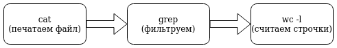

Сами очереди находятся в 'стрелочках'

## !!! НАДО ЗАПОМНИТЬ !!!

**ОБА ПРОЦЕССА РАБОТАЮТ ПАРАЛЛЕЛЬНО**

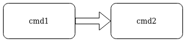

Пример:

```
$ yes | cat
y
y
y
y
y
y
^C
```

Если бы процессы работали по очереди, мы бы вывода НЕ увидели

## Что у нас сейчас

Мы с вами прошли `fork` и `exec`

Нам хочется уметь делать так же

Но строчки такого вида не работают

```
execlp("seq", "seq", "5", "|", "wc", NULL);
```

**вопрос на вспомнить: почему?**

Ну и pipe-ы помогут это исправить))

## pipe & dup2

Вызов pipe создает очередь с двумя файловыми дескрипторами - один для чтения, второй для записи

**man 2 pipe**

```
SYNOPSIS
       #include <unistd.h>

       int pipe(int pipefd[2]);
...
```

Один в один))

**Как запомнить?**

> *pipefd[0]* refers to the read of the pipe

> *pipefd[1]* refers to the write of the pipe

Мы все помним, что 0 - поток ввода (*stdin*), 1 - поток вывода (*stdout*). Тут так же

**dup2**

dup2 нужен, чтобы ПОДМЕНИТЬ один дескриптор на другой

**man 2 dup**

```
SYNOPSIS
#include <unistd.h>
...
       int dup2(int oldfd, int newfd);
...
```

**Зачем это нужно?** - вопрос логичен

Ответ тоже логичен - **чтоб подменять stdin, stdout, stderr**

## Собственно все!) Теперь давайте научимся работать с этим

```python
#include <unistd.h>
#include <stdio.h>
#include <sys/wait.h>
#include <fcntl.h>
```

### Пример работы с pipe

```python
{
    int pipefd[2];

    // Создаем очередь
    pipe(pipefd);

    char str[] = "Hello, pipe";
    write(pipefd[1], str, sizeof(str));

    char buffer[128];
    read(pipefd[0], buffer, sizeof(buffer));

    printf("read: %s", buffer);

    // Закрываем за собой!!!
    close(pipefd[0]);
    close(pipefd[1]);
}
```

```
read: Hello, pipe
```

То же самое, но с обработкой ошибки pipe

```python
{
    int pipefd[2];
    if (pipe(pipefd) == -1) {
        perror("pipe");
    }

    char str[] = "Hello, pipe";
    write(pipefd[1], str, sizeof(str));

    char buffer[128];
    read(pipefd[0], buffer, sizeof(buffer));

    printf("read: %s\n\n", buffer);

    printf("pipefd[0] = %d\npipefd[1] = %d", pipefd[0], pipefd[1]);

    // Закрываем за собой!!!
    close(pipefd[0]);
    close(pipefd[1]);
}
```

```
read: Hello, pipe

pipefd[0] = 60
pipefd[1] = 61
```

А вот сейчас важно!

Очередь лучше закрывать полностью (или хотяб все потоки ввода)

### Теперь давайте посмотрим на dup2

Создадим вот такой вот файлик

```
$ cat input.txt
hello
123
abacabadabacaba
```

Теперь запустим `cat` и передадим ему на вход этот файлик

```python
{
    // Открываем файлик
    int fd = open("input.txt", O_RDONLY);

    // создаем процесс
    if (fork() == 0) {
        // Подменяем поток ввода
        dup2(fd, 0);

        // just exec
        execlp("cat", "cat", NULL);
    }
    wait(NULL);

    // Закрываем
    close(fd);
}
```

```
hello
123
abacabadabacaba
```

### pipe как в bash

**А ВОТ СЕЙЧАС СЛЕДИМ ЗА РУКАМИ!!! САМЫЙ ВАЖНЫЙ МОМЕНТ ЛЕКЦИИ**

Сейчас расскажу вам сказку))

Жил был процесс... и было у него 3 потока ввода-вывода

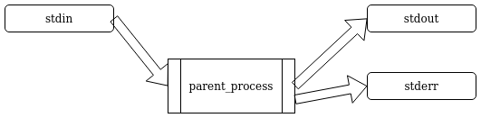

И вот создал он себе очередь

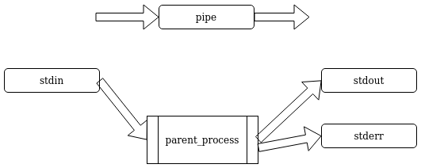

А потом появился у него дочерний процесс

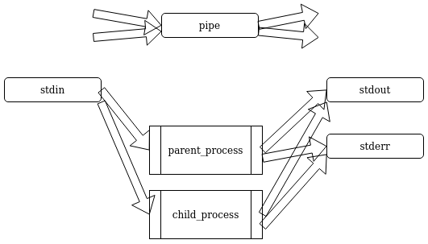

И началась камасутра с перенаправлением потоков...

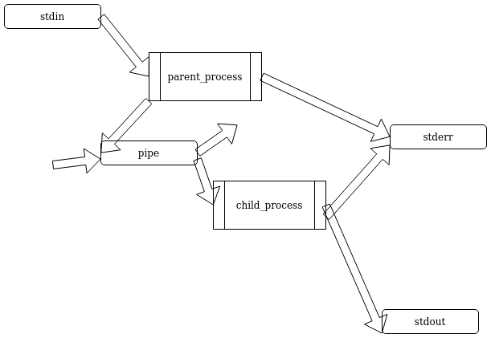

И жил дочерний процесс вечно, ибо незакрытая очередь погрузила его в вечный сон

И жил родительский процесс вечно, ибо ожидание смерти дочернего так же погрузило его в вечный сон...

**Мораль - закрывайте потоки!)**

Короче делайте как надо, а как не надо не делайте

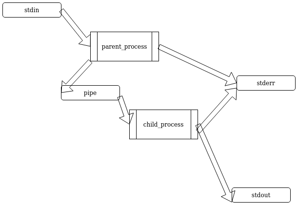

Делаем как надо

(только с тремя процессами)

```
#include <unistd.h>
#include <stdio.h>
#include <sys/wait.h>
#include <fcntl.h>


int main() {
    int pipefd[2];

    if (pipe(pipefd) == -1) {
        perror("pipe");
    }

    // producer
    pid_t pid_p = fork();
    if (pid_p == 0) {
        dup2(pipefd[1], 1);
        close(pipefd[0]); // читать из очереди мы не будем

        printf("Hello!!!\n");
        printf("I am writing to stdout!!!\n");

        _exit(0);
    } else if (pid_p < 0) {
        perror("producer");
    }

    // consumer
    pid_t pid_c = fork();
    if (pid_c == 0) {
        dup2(pipefd[0], 0);
        close(pipefd[1]); // писать в очередь мы не будем (ОБЯЗАТЕЛЬНО)

        execlp("cat", "cat", NULL);
    } else if (pid_c < 0) {
        perror("consumer");
    }

    // ОБЯЗАТЕЛЬНЫЙ ШАГ!
    close(pipefd[0]);
    close(pipefd[1]);

    // спим
    waitpid(pid_p, NULL, 0);
    waitpid(pid_c, NULL, 0);
}
```

Запускаем

[output not shown]

Ну если вы поняли сказку, то вы решите контест

### Нулевка

Реализуйте программу, которая принимает два аргумента: CMD - команда для запуска, IN - имя файла, направляемого на ввод.

Программа должна запускать указанную команду, передавая ей на вход содежимое файла IN.

На стандартный поток вывода вывести количество байт, которое было записано запущенной командой в стандартный поток вывода. Вывод самой команды никуда выводить не нужно.

## Thx)

Спасибо за внимание!))